# Homework 2

# Problem Set 9, Concepts

## 1

### (a)

$β_o$ is the intercept value when the explanatory variable, X, is in region 0 of the step function (region used as the baseline) in the regression model.

### (b)

$β_k$ is the difference of intercept values when X is in the last region (region k) and $β_o$, the baseline region.

# Problem Set 10, Applications

## 1

### (a)

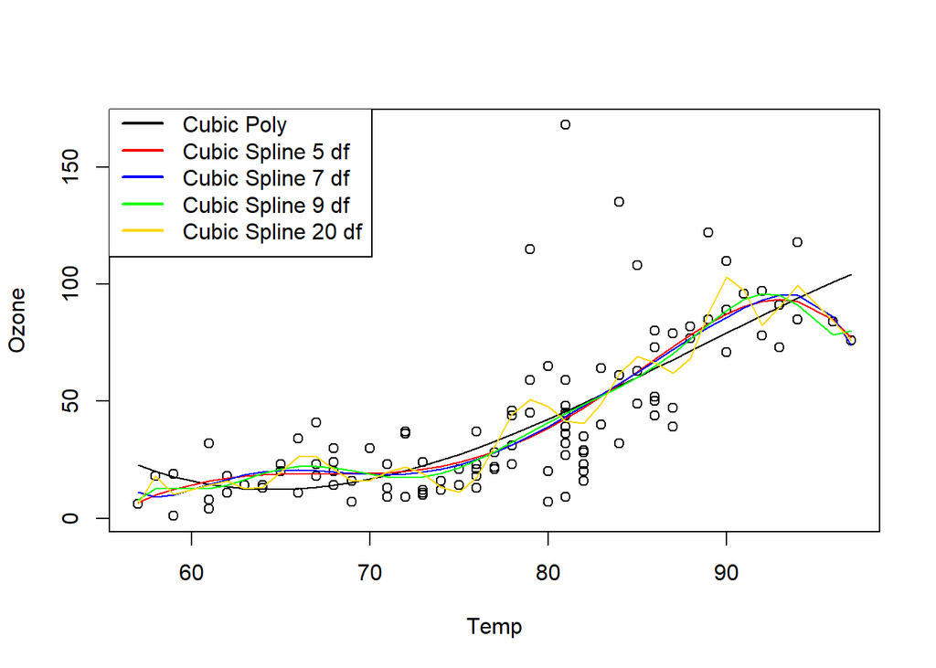

```r
### Fit polynomial regression models
fit.poly.3 <- lm(Ozone ~ poly(Temp, degree = 3), data = AQ)

### Fit basis splines
library(splines)

fit.basis.5 <- lm(Ozone ~ bs(Temp, degree = 5), data = AQ)
fit.basis.7 <- lm(Ozone ~ bs(Temp, degree = 7), data = AQ)
fit.basis.9 <- lm(Ozone ~ bs(Temp, degree = 9), data = AQ)
fit.basis.20 <- lm(Ozone ~ bs(Temp, degree = 20), data = AQ)

### Predicting
Temp.sort <- data.frame(Temp = sort(AQ$Temp))
pred.poly.3 <- predict(fit.poly.3, Temp.sort)
pred.basis.5 <- predict(fit.basis.5, Temp.sort)
pred.basis.7 <- predict(fit.basis.7, Temp.sort)
pred.basis.9 <- predict(fit.basis.9, Temp.sort)
pred.basis.20 <- predict(fit.basis.20, Temp.sort)

### Plots
with(AQ, plot(Temp, Ozone))
lines(Temp.sort$Temp, pred.poly.3)
lines(Temp.sort$Temp, pred.basis.5, col = 'red')
lines(Temp.sort$Temp, pred.basis.7, col = 'blue')
lines(Temp.sort$Temp, pred.basis.9, col = 'green')
lines(Temp.sort$Temp, pred.basis.20, col = 'gold')
legend(x = 55, y = 180, legend = c(
    "Cubic Poly", "Cubic Spline 5 df",
    "Cubic Spline 7 df", "Cubic Spline 9 df", "Cubic Spline 20 df"
  ),
  lty = "solid", col = c('black', 'red', 'blue', 'green', 'gold'), lwd = 2
)
```

### (b)

Looking at the graph, the cubic polynomial seems to have the most bias.

### (d)

I would choose the 5-df cubic spline. It seems to capture the data relatively well with no clear overfitting, and no random end-point fluctuations.